# MS-C1620 Statistical Inference

### Class exercise

*To be solved at the exercise session.*

1. The file `data_children.txt` contains data on children’s ages (`age`, in months) and heights (`height`, in centimeters). Investigate whether there is a linear relationship between the two variables.
   1. Read the file into R using the command `read.table`.
   2. Draw a scatter plot of `age` and `height`.
   3. Fit a linear model to the data using `height` as a response variable.
   4. Add the fitted regression line to the scatter plot. Does the fit appear good?
   5. Interpret the estimated regression coefficient of `age` and the $R^2$-value of the model.

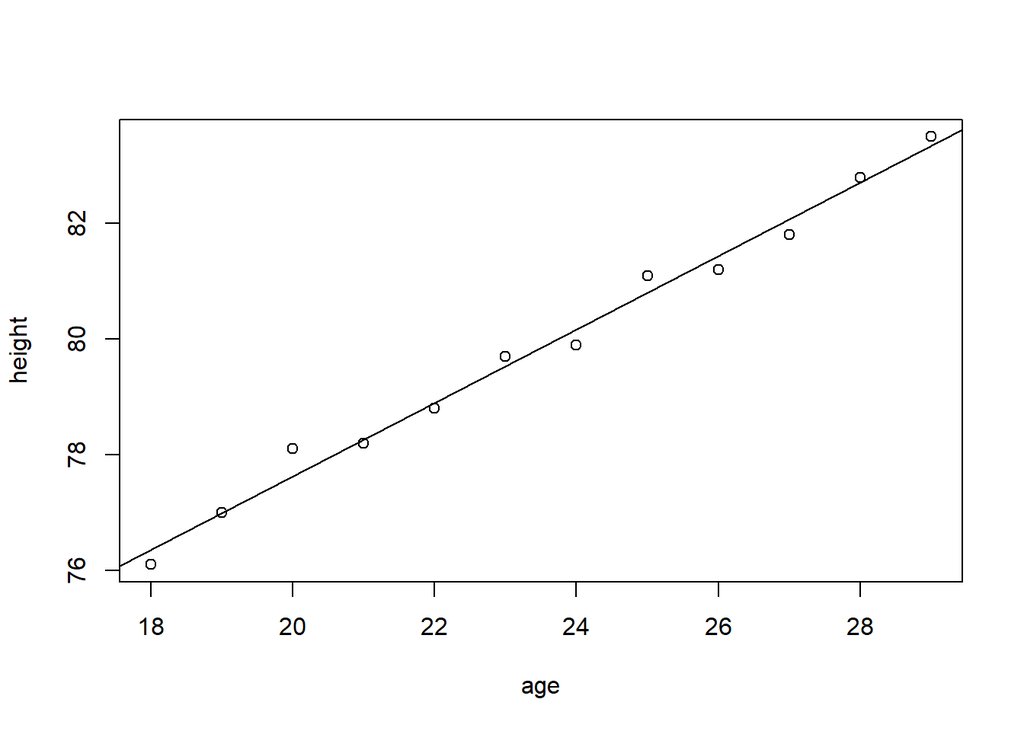

```r
# a.
# Replace "params$your_path_here_1" with your path to the .txt file in the code below (and remember that "/" is used to navigate sub-folders in R)
children <- read.table(params$your_path_here_1, sep = "\t", header = TRUE)


# b.
plot(children)


# c.
children_lm <- lm(height ~ age, data = children)


# d.
# The line appears to fit the data well.
abline(children_lm)
```

```r
# e.
summary(children_lm)
```

```
##
## Call:
## lm(formula = height ~ age, data = children)
##
## Residuals:
##      Min       1Q   Median       3Q      Max
## -0.27238 -0.24248 -0.02762  0.16014  0.47238
##
## Coefficients:
##             Estimate Std. Error t value Pr(>|t|)
## (Intercept)  64.9283     0.5084  127.71  < 2e-16 ***
## age           0.6350     0.0214   29.66 4.43e-11 ***
## ---
## Signif. codes:  0 '***' 0.001 '**' 0.01 '*' 0.05 '.' 0.1 ' ' 1
##
## Residual standard error: 0.256 on 10 degrees of freedom
## Multiple R-squared:  0.9888, Adjusted R-squared:  0.9876
## F-statistic:   880 on 1 and 10 DF,  p-value: 4.428e-11
```

```r
# The regression coefficient is about 0.64, meaning that for an increase of a single month in a child's age, the expected value of her/his height goes up by 0.64cm.

# The coefficient of determination is ~0.99, indicating an excellent fit.
```

2. The file `data_tobacco.txt` contains data on cigarette consumption and lung cancer incidences from 11 different countries. The variable `consumption` describes the yearly consumption of cigarettes per capita in 1930 and the variable `incidence` tells the lung cancer incidence rates per 100 000 people in 1950. *(Recall exercise 7.2)*
   1. Read the file into R using the command `read.table`.
   2. Draw a scatter plot of `consumption` and `incidence`.
   3. Fit a linear model to the data using `incidence` as a response variable.
   4. Add the fitted regression line to the scatter plot. Does the fit appear good?
   5. Interpret the estimated regression coefficient and $p$-value of `consumption`.
   6. Interpret the $R^2$-value of the model.
   7. Drop USA from the data, redo the previous analysis and compare the results to those obtained with the full data. What happened?

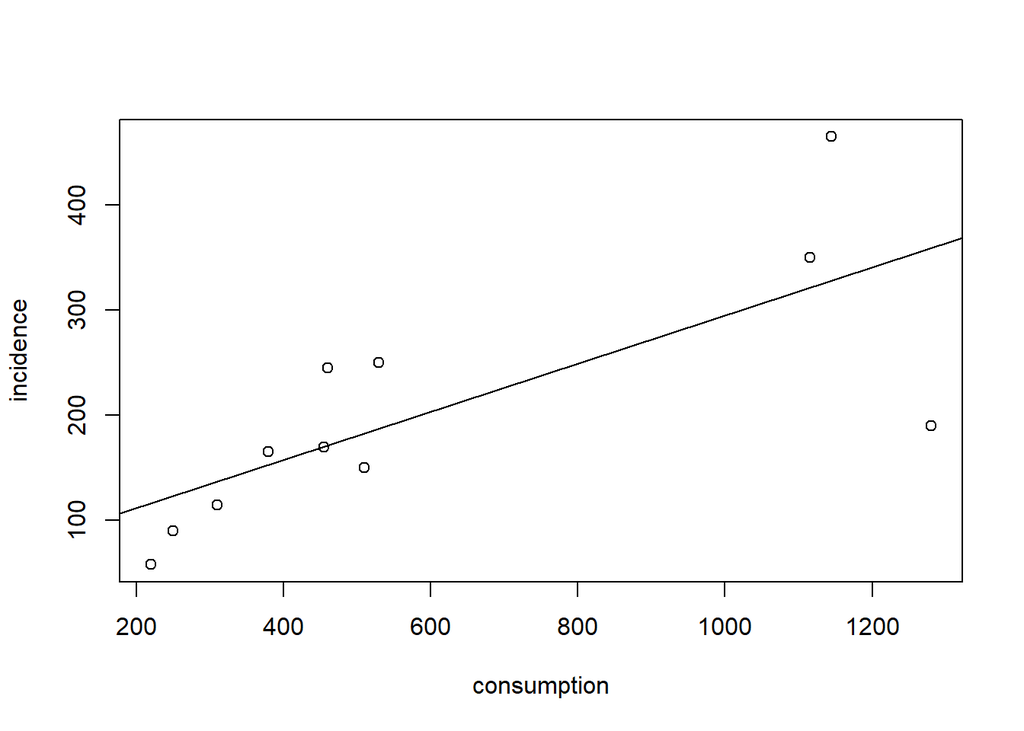

```r
# a.
# Replace "params$your_path_here_2" with your path to the .txt file in the code below (and remember that "/" is used to navigate sub-folders in R)
tobacco <- read.table(params$your_path_here_2, sep = "\t", header = TRUE)


# b.
plot(incidence ~ consumption, data = tobacco)
# text(tobacco$consumption, tobacco$incidence, labels = tobacco$country, cex= 0.7, pos=3)


# c.
tobacco_lm <- lm(incidence ~ consumption, data = tobacco)


# d.
# The line appears to miss most of the points in favour of trying to reach closer to the outlier in the lower right corner.
abline(tobacco_lm)
```

```r
# e.
summary(tobacco_lm)
```

```
##
## Call:
## lm(formula = incidence ~ consumption, data = tobacco)
##
## Residuals:
##      Min       1Q   Median       3Q      Max
## -169.016  -32.813    0.004   45.804  136.914
##
## Coefficients:
##             Estimate Std. Error t value Pr(>|t|)
## (Intercept) 65.74886   48.95871   1.343  0.21217
## consumption  0.22912    0.06921   3.310  0.00908 **
## ---
## Signif. codes:  0 '***' 0.001 '**' 0.01 '*' 0.05 '.' 0.1 ' ' 1
##
## Residual standard error: 84.13 on 9 degrees of freedom
## Multiple R-squared:  0.549,  Adjusted R-squared:  0.4989
## F-statistic: 10.96 on 1 and 9 DF,  p-value: 0.009081
```

```r
# The regression coefficient is about 0.23, meaning that for an increase of a single smoked cigarette in year per capita, the expected value of the incidence of lung cancer (20 years aftewards) goes up by 0.23 units.
# The p-value related to the coefficient is small (below the standard 0.05), meaning that this effect is most likely real, and not just caused by randomness (assmuing the model assumptions hold).

# f.
# The R-squared is somewhat high (~0.55), meaning that the model succeeds in explaining a bit over half of the variation of the response variable (however, compare this to the R-squared without the outlier in part g.)


# g.
tobacco <- tobacco[-7, ]
# Running the previous code to remove USA and then redoing the steps yields:
# Examination of the scatter plot shows that the line fits the data much better now
# Coefficient of "consumption" ~ 0.36 (the outlier had "contaminated" the value for the full data)
# p-value is much smaller (removing the outlier helped the model see clearer that the perceived effect is not just randomness)
# R-squared increased to ~0.89, a much better fit.

# NOTE: Again, in practice we should have some clear reason for removing U.S. from the data. We'll investigate this closer next time.
```

3. **(Optional)** Investigate how much a single outlier can affect the results of a linear model: Create a small data set that has a perfect linear relationship between its two variables (such a model has the explanatory variable $p$-value equal to 0 and the coefficient of determination equal to 1). Then, add a single outlying data point and see how much you can change the $p$-value and the coefficient of determination by varying the outlier’s value.